# Brochure

## About the course

This 15-hour course fills the skill gap in mid-career automotive engineers and research scientists by teaching how foundation models work and where they apply in the automotive domain — from **battery degradation forecasting** to **ADAS trajectory planning**.

The course ends with a **capstone project** where each engineer writes a deployment proposal for their own product area, leaving with working code, peer feedback, and a concrete next step.

## What you learn

### Foundations and generative models

Bayesian thinking, neural networks and Transformers as function approximators, and the generative model families (VAEs, GANs, diffusion) that underpin modern automotive validation.

### Diffusion, forecasting, and diagnostics

Diffusion mechanics and trajectory generation for ADAS, synthetic scenario and defect generation, time-series foundation models, and anomaly detection for battery, vibration, and CAN-bus data.

### VLMs, VLAs, world models, and Capstone

Fine-tuning with LoRA, imitation learning and diffusion policy for robotics, VLA architectures for perception-to-action control, world models for autonomous driving, and integration with classical control and safety certification.

- **VLM and VLA architectures.** RT-2, OpenVLA, pi-zero, and GR00T N1 for vision-language-action perception-to-action control.
- **VLMs and VLAs across industries.** Visual quality inspection in semiconductor fab, warehouse logistics, and multimodal technician co-pilots.
- **World models and World Action models for engineering systems.** Generative physical simulation, digital twins, and learned environment dynamics replacing hand-crafted simulators.
- **The foundation model stack.** Integrating diffusion planners, TSFMs, VLAs, and world models with classical control, SCADA, and safety certification.
- **Capstone workshop.** Each engineer develops a foundation-model deployment proposal for their own product area and industry domain.

## Capstone project

### Deployment proposal

Each student arrives with a real product-area problem that could benefit from a foundation-model approach.

**The workshop.** Across the final sessions, participants scope the problem, sketch an architecture, prototype in Python or MATLAB, and defend the design under structured peer critique.

**Deliverable.** A written deployment proposal, working prototype code, peer feedback, and a *concrete next step* to bring back to the team.

# Foundational course taught to your team at your company’s location.

Send a short note with your team’s product areas, headcount, and preferred dates. We reply within two business days with a scoping call.

**abhishek.rimc@gmail.com**

## Who benefits & how

- **Engineering managers.** Understand exactly where foundation models will succeed vs. fail. Cut through the hype to improve resource allocation, reduce risk, and guide product strategy.
- **Research scientists.** Gain a common language to communicate across engineering and management, bridging the gap between theoretical AI and concrete business value.
- **Engineers.** Move past academic theory to hands-on implementation. Accelerate your career by delivering working code and deployment proposals that directly impact your product area.

## 6 Week Schedule

- **Week 1-4:** 1 hour online lectures on MWF only for the contracting company people and 1 hour of office hours on Friday.
- **Week 5:** on site 1 hour lecture on Monday, Tuesday, and Wednesday and one hour office hour on Monday, Tuesday, and Wednesday.
- **Week 6:** Remote capstone review and support.

### Prerequisites

- Linear algebra background
- Exposure to probability and optimization
- In-class coding in Python or MATLAB

## Selected recent work

- **Probabilistic contraction analysis of iterated random operators.** *IEEE Trans. Automatic Control*, 2024.
- **Dynamic watermarking for finite Markov decision processes.** *IEEE Open J. Control Systems*, 2025.
- **Robustness to modeling errors in risk-sensitive MDPs.** *IEEE Open J. Control Systems*, 2025.
- **Model-free change-point detection for mixing processes.** *IEEE Open J. Control Systems*, 2024.

## Course principles

- **No hype demos.** Every model taught explained with its failure modes. If we can’t state where it breaks, we clearly state it.
- **No black-box library calls.** Diffusion, TSFMs, and VLAs are taught end-to-end — noise schedule to sampler. Everyone can derive it on a whiteboard.
- **Every session ends with a stop/go rule.** A written decision framework per technique: does it belong in your product area, at what phase?
- **Develop a common language and a shared understanding.** Engineers, researchers, and managers can all speak the same language and deliver the right solutions, blazing fast.

# Foundation Models for Engineering Systems

*A 15-hour applied course for mid-career engineers, managers, and research scientists.*

[figure not shown]

## Instructor: Prof. Abhishek Gupta

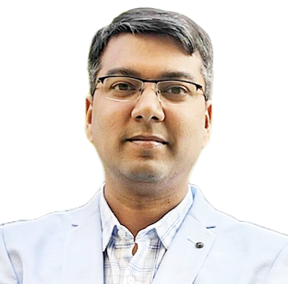

Associate Professor of *Electrical and Computer Engineering* at **The Ohio State University** and **Founder & CEO of Ensemble Control Inc.** (robotics for extreme environments). Author of **70+ publications** in leading journals and conferences on reinforcement learning, world models, and stochastic control for autonomous vehicles, energy systems, and robotics. Ph.D. Aerospace (2014, UIUC); B.Tech. IIT Bombay (2009). Three OSU patent applications, two commercialized. **Lumley Research Award (2019)** for foundational contributions to stochastic control.

### Contact Information

- https://gupta706.github.io/
- +1 (217) 819 6382